# Análisis de la distribución de las instituciones de educación especial en el Perú durante el año 2015

#### **Importancia y objetivo principal**

La educación especial permite que el individuo con discapacidad se desarrolle correctamente para alcanzar su mayor potencial evolutivo dentro de una sociedad integradora. En el país alrededor de 38.5% de personas con discapacidad no tiene acceso a la educación. De las que sí tienen acceso, sólo el 3.61% accede a la escuela de educación especial (Estudios CEEDIS 2005). Es por ello que el objetivo principal de nuestro estudio es señalar cómo están distribuidas las instituciones de educación especial en el Perú en el año 2015, tomando las variables de departamentos, provincias, número de profesores y número de alumnos. Esta es la [base de datos](https://n9.cl/9xayr) que utilizaremos.

#### **Definición de nuestra población, unidad muestral y el tipo de muestra**

| Definición | Descripción |
| --- | --- |
| **Población:** | Todas las instituciones formales de educación especial ubicadas en el Perú durante el año 2015. |
| **Unidad muestral:** | Una institución formal de educación especial ubicada en el Perú durante el año 2015. |
| **Tipo de muestreo:** | Dado que el estudio abarca a toda la población, las técnicas de muestreo resultan impertinentes, ya que estas solo sirven cuando se trabaja con solo un fragmento de la población. |

#### **Lectura y limpieza de datos**

Los datos se obtuvieron de la página de la INEI, la cual tiene un total de 487 observaciones y 13 variables. Para evitar errores y que influyan de mala manera con los descriptores numéricos se realiza la limpieza de la data eliminando los NA’s y valores 0 en las variables numéricas (como 0 docentes, o 0 alumnos), los cuales consideramos errados y sin sentido en nuestro análisis. A su vez, existen “datos atípicos” los cuales consideramos son producto de la centralización de recursos y población que existe en el país, mas no de un error al momento de la contabilización.

Por ende, el proceso para limpiar la data fue el siguiente:

##### **Función para eliminar los 0’s en variables numéricas**

```r
borrarDatos <- function(D, col1, col2, col3){
  for(i in 1:nrow(D)){
    if(D[i, col1]==0 | D[i, col2]==0 | D[i, col3]==0){
      D[i, col1] = NA
    }
  }
  na.omit(D)
}
```

##### **Limpieza final**

```r
Data <- read_csv("Col_Espe.csv")
Data <- na.omit(Data)
Data <- borrarDatos(Data, 11,12,13)
```

| Código modular | Código de local | Nombre de IE | Nivel / Modalidad | Forma | Gestión / Dependencia | Dirección de IE | Departamento | Provincia | Distrito | Alumnos (2015) | Docentes (2015) | Secciones (2015) |
| --- | --- | --- | --- | --- | --- | --- | --- | --- | --- | --- | --- | --- |
| 0909721 | 015775 | SEÑOR DE LOS MILAGROS | Educación Especial | Escolarizado | Pública - Sector Educación | AVENIDA SIMON BOLIVAR S/N | Ancash | Huaraz | Huaraz | 57 | 20 | 11 |
| 0681726 | 026905 | SAN ANTONIO DE PADUA | Educación Especial | Escolarizado | Pública - Sector Educación | JIRON BOLOGNESI S/N | Ancash | Huaylas | Caraz | 22 | 3 | 7 |
| 1003151 | 037602 | CEBE AULA DE EDUCACION ESPECIAL 01 SANTA | Educación Especial | Escolarizado | Pública - Sector Educación | MZ W LOTE 1 | Ancash | Santa | Santa | 23 | 3 | 7 |
| 1000306 | 038041 | CEBE 03 | Educación Especial | Escolarizado | Pública - Sector Educación | JIRON 31 | Ancash | Santa | Nuevo Chimbote | 78 | 24 | 10 |
| 0570226 | 034793 | CEBE 01 | Educación Especial | Escolarizado | Pública - Sector Educación | MZ P LOTE 24-25 | Ancash | Santa | Chimbote | 123 | 36 | 11 |
| 0359323 | 035641 | CEBE FE Y ALEGRIA 42 | Educación Especial | Escolarizado | Pública - En convenio | AVENIDA JOSE PARDO 4071 MZ 13 LOTE 01 | Ancash | Santa | Chimbote | 145 | 41 | 17 |
| 1001627 | 529058 | PRITE LA VICTORIA | Educación Especial | No escolarizado | Pública - Sector Educación | MZ 6 LOTE 26-B ZONA II | Ancash | Santa | Chimbote | 84 | 9 | 5 |
| 0818518 | 022323 | 02 AGUSTIN EVANS | Educación Especial | Escolarizado | Pública - Sector Educación | CALLE MARISCAL SUCRE | Ancash | Casma | Casma | 16 | 7 | 8 |
| 1042399 | 026118 | 04 VIRGEN DEL ROSARIO | Educación Especial | Escolarizado | Pública - Sector Educación | CARRETERA PANAMERICANA NORTE KM.293 | Ancash | Huarmey | Huarmey | 47 | 7 | 12 |
| 0637330 | 072407 | CENTRO ESPECIAL MOLLENDO | Educación Especial | Escolarizado | Pública - Sector Educación | CALLE PUNO 710 | Arequipa | Islay | Mollendo | 41 | 10 | 11 |

[output cut: 463 more lines]

Finalmente, los valores atípicos en esta investigación son aquellos que cumplen tal que: q < Q1 - 1.5(Q3-Q1) o q > Q3+1.5(Q3-Q1) . Donde q es equivalente al valor en cuestión, Q3 es el tercer cuartil y Q1 es el primer cuartil.

#### **Clasificación de las variables**

La data obtenida consta de 13 variables de las cuales la mayoría resulta ser del tipo categórica nominal. Una tabla es presentada para determinar el tipo de variable y una descripción de la variable:

| Variable | Tipo de variable | Descripción |
| --- | --- | --- |
| **Código modular** | Categórica ordinal | Consta de 7 dígitos y se encarga de identificar al centro educativo. |
| **Código local** | Categórica ordinal | Identifica su ubicación a partir de su dirección, es un código autorizado a una I.E. |
| **Nombre** | Categórica nominal | Nombre de las instituciones educativas. |
| **Nivel** | Categórica nominal | Indica el tipo de educación que se brinda. (Educación especial en nuestro caso). |
| **Formación** | Categórica nominal | Indica si la institución está escolarizada. |
| **Gestión** | Categórica nominal | Indica si la institución es de control público o privado. |
| **Dirección** | Categórica nominal | Indica la ubicación exacta del establecimiento. |
| **Departamento** | Categórica nominal | Indica el departamento donde se encuentra el establecimiento. |
| **Provincia** | Categórica nominal | Indica la provincia donde se encuentra el establecimiento. |
| **Distrito** | Categórica nominal | Indica el distrito donde se encuentra el establecimiento. |
| **Alumno** | Numérica discreta | Indica la cantidad de estudiantes inscritos en la institución. |
| **Docente** | Numérica discreta | Indica la cantidad de profesores que trabajan en la institución. |
| **Sección** | Numérica discreta | Indica la cantidad de salones/grupos de estudio en la institución. |

```
##  Código modular     Código de local    Nombre de IE       Nivel / Modalidad
##  Length:473         Length:473         Length:473         Length:473
##  Class :character   Class :character   Class :character   Class :character
##  Mode  :character   Mode  :character   Mode  :character   Mode  :character
##
##
##
##     Forma           Gestión / Dependencia Dirección de IE    Departamento
##  Length:473         Length:473            Length:473         Length:473
##  Class :character   Class :character      Class :character   Class :character
##  Mode  :character   Mode  :character      Mode  :character   Mode  :character
##
##
##
##   Provincia           Distrito         Alumnos (2015)  Docentes (2015)
##  Length:473         Length:473         Min.   :  1.0   Min.   : 1.000
##  Class :character   Class :character   1st Qu.: 14.0   1st Qu.: 2.000
##  Mode  :character   Mode  :character   Median : 25.0   Median : 5.000
##                                        Mean   : 39.7   Mean   : 7.932
##                                        3rd Qu.: 50.0   3rd Qu.:10.000
##                                        Max.   :310.0   Max.   :54.000
##  Secciones (2015)
##  Min.   : 1.000
##  1st Qu.: 4.000
##  Median : 7.000
##  Mean   : 7.474
##  3rd Qu.:10.000
##  Max.   :25.000
```

#### **Evaluación de las variables numéricas con respecto a las Instituciones Educativas**

Para iniciar con la visualización de los datos es necesario entender como es que se comportan, para ello decidimos que sería prudente mostrar los valores de media, primer cuartil, tercer cuartil, máximo valor y la desviación estándar.

[output not shown]

A continuación un resumen de los valores de los descriptores numéricos para las variables ALUMNOS y DOCENTES:

| Descriptores numéricos para alumnos |  |
| --- | --- |
| Media | ~ 40 alumnos |
| 1° Cuartil | 14 alumnos |
| Mediana | 25 alumnos |
| 3° Cuartil | 50 alumnos |
| Máximo valor | 310 alumnos |
| Desviación estándar | ~ 40 alumnos |

| Descriptores numéricos para docentes |  |
| --- | --- |
| Media | ~ 8 docentes |
| 1° Cuartil | 2 docentes |
| Mediana | 5 docentes |
| 3° Cuartil | 10 docentes |
| Máximo valor | 54 docentes |
| Desviación estándar | ~ 9 docentes |

#### **Boxplot y gráfico de violin**

Estos descriptores gráficos nos permitirán observar todo aquello que mencionamos: la dispersión, tendencia y concentración de los valores numéricos, valores atípicos y el tipo de sesgo que tienen. Cabe mencionar que el gráfico de violín junto con el boxplot ayudan a percibir mucho mejor la concentración de los datos para ciertos rangos.

```r
c1 <- D3 %>%
  ggplot(aes(x="", y=Docentes, fill=Docentes)) +
    geom_boxplot() +
    scale_fill_viridis(discrete = FALSE) +
    geom_jitter(color="blue", size=0.7, alpha=0.5) +
    theme(
      legend.position="none",
      plot.title = element_text(size=11)
    ) +
    xlab("")
c2 <- D3 %>%
  ggplot( aes(x="", y=Alumnos, fill=Alumnos)) +
    geom_boxplot() +
    scale_fill_viridis(discrete = FALSE) +
    geom_jitter(color="blue", size=0.7, alpha=0.5) +
    theme(
      legend.position="none",
      plot.title = element_text(size=11)
    ) +
    xlab("")
```

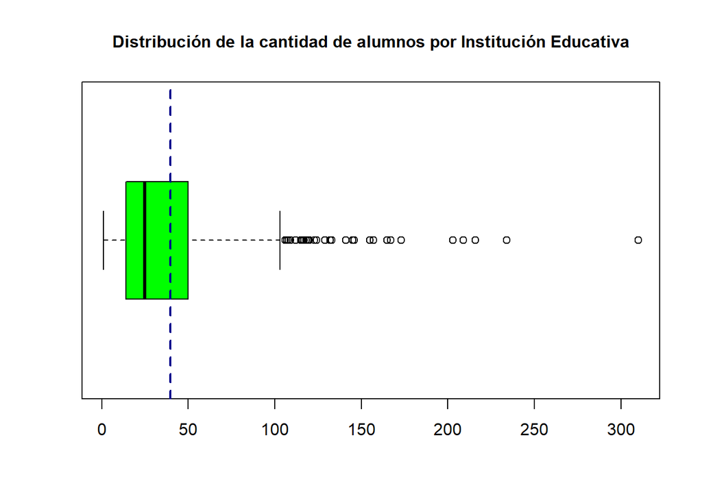

```r
r2 <- boxplot(D3$Alumnos, horizontal = 1, main="Distribución de la cantidad de alumnos por Institución Educativa",cex.main=1, col ="green")
abline(v=mean(D3$Alumnos,na.rm = TRUE),col="darkblue",lwd=2,lty=2)
```

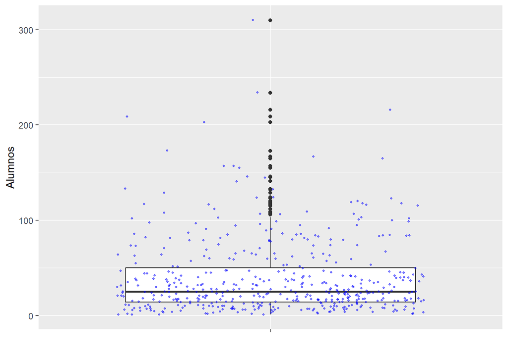

```r
c2
```

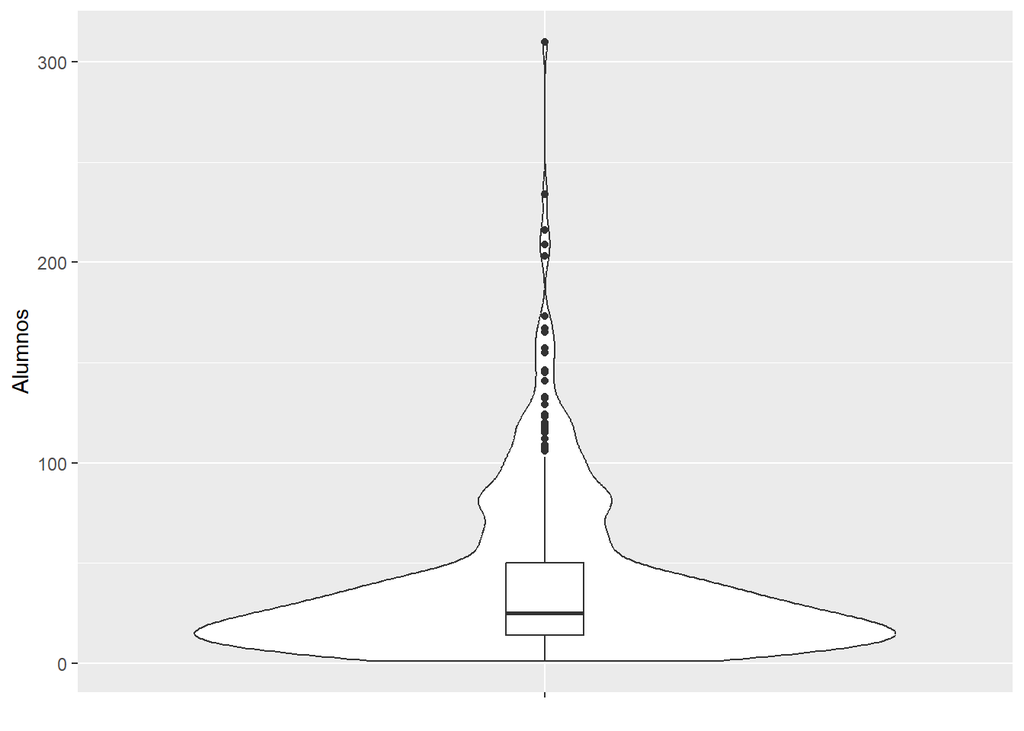

```r
p2
```

Se observa una gran cantidad de datos atípicos que se diferencian considerablemente del resto de datos. Es por ello que la media es notablemente mayor que la mediana.

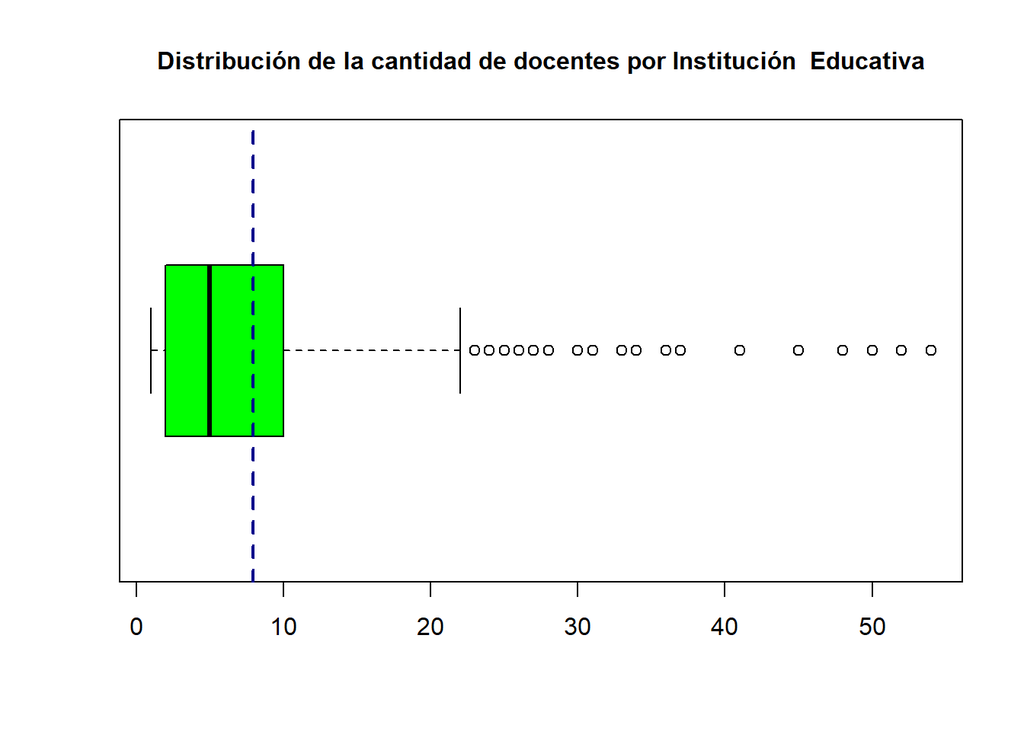

```r
r1 <- boxplot(D3$Docentes, horizontal = 1, main="Distribución de la cantidad de docentes por Institución  Educativa", cex.main=1, col ="green")
abline(v=mean(D3$Docentes,na.rm = TRUE),col="darkblue",lwd=2,lty=2)
```

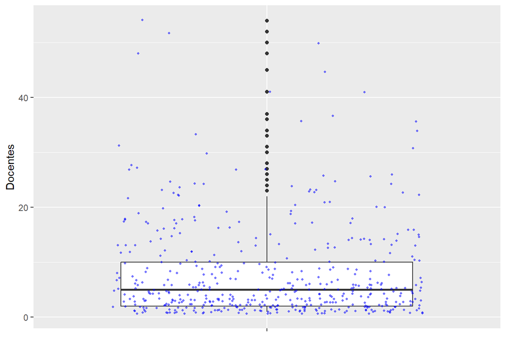

```r
c1
```

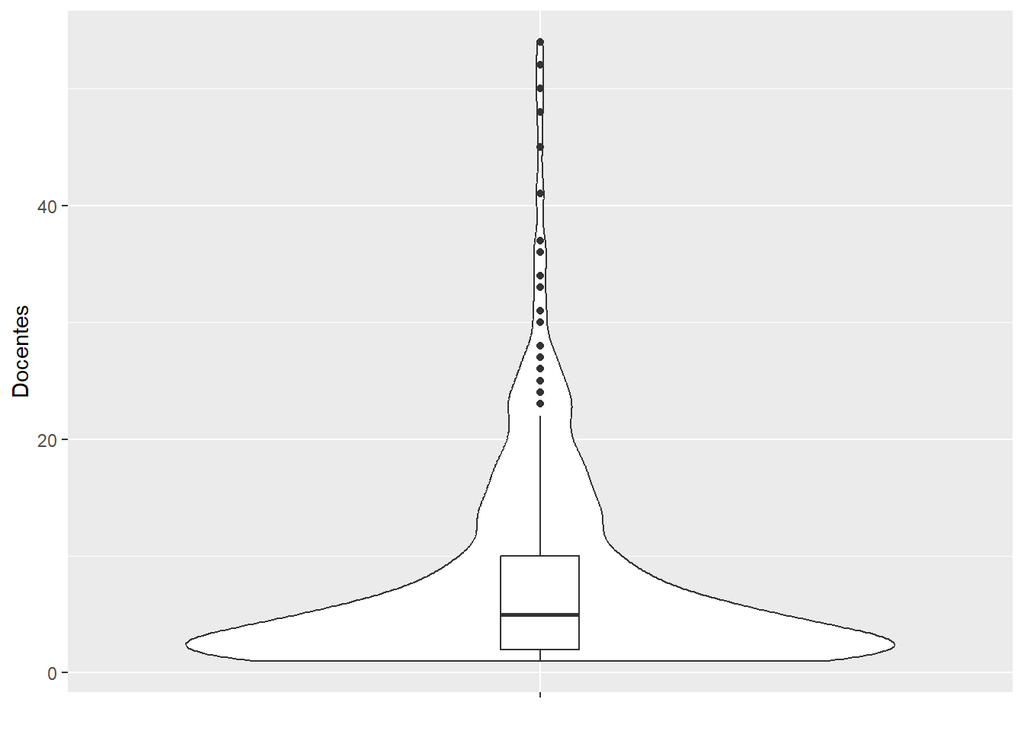

```r
p1
```

Si se quisiera ver exactamente en que intervalos se condensa más la población podríamos utilizar la siguiente herramienta, esta nos proporciona un ambiente agil, ya que podemos interactuar directamente con el gráfico y obtener datos especificos en puntos que consideremos importantes:

**Para el caso de alumnos**

```r
X1 <- D3 %＞% plot_ly(x = "", y = ~Alumnos, type = 'violin',
                     box = list(visible = TRUE, width = 0.2))

htmlwidgets::saveWidget(X1, "X1.html")
display_html('＜iframe src="X1.html" width=600 height=600 frameborder="0"＞＜/iframe＞')
```

**Para el caso de docentes**

```r
X2 <- D3 %＞% plot_ly(x = "", y = ~Docentes, type = 'violin',
                     box = list(visible = TRUE, width = 0.2))

htmlwidgets::saveWidget(X2, "X2.html")
display_html('＜iframe src="X2.html" width=600 height=600 frameborder="0"＞＜/iframe＞')
```

Estos mismos requieren de una extensión de R. Es por ello que se presentan los archivos X1.html y x2.html para su visualización e interacción.

##### **Apartado de regresión para las variables alumnos y docentes**

Seguidamente, sería prudente observar si existe una relación lineal entre estas dos variables numéricas a traves del gráfico de dispersión:

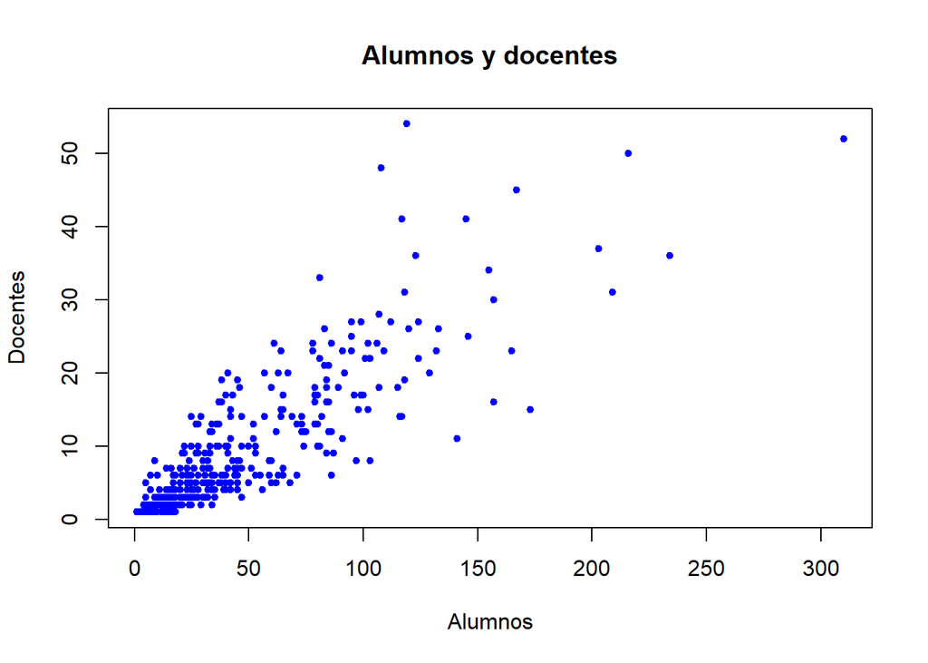

```r
plot(Data$`Alumnos (2015)`, Data$`Docentes (2015)`, pch = 20, col = "blue", main = "Alumnos y docentes", xlab= "Alumnos", ylab = "Docentes")
```

A simple vista parece tener una relación directamente proporcional. Esto lo podemos confirmar con los valores de covarianza y correlación. El dato de la covarianza unicamente nos proporciona información acerca del cambio que sufre una variable al momento de alterar la otra, por lo que lo unico que nos interesa es el signo que tiene. Por otro lado, la correlación es mucho más directa en afirmar qué tan cerca está el conjunto de datos para poder considerarla como un relación lineal. El valor que puede tomar se encuentra entre -1 y 1.

```r
# Covarianza
cov(Data$`Alumnos (2015)`, Data$`Docentes (2015)`)
```

```
## [1] 301.9795
```

El signo positivo de la covarianza nos indica una relación “directamente proporcional”.

```r
# Correlación
cov(Data$`Alumnos (2015)`, Data$`Docentes (2015)`)/(sd(Data$`Alumnos (2015)`)*(sd(Data$`Docentes (2015)`)))
```

```
## [1] 0.8601732
```

```r
cor(data2)
```

```
##           X1        X2
## X1 1.0000000 0.8601732
## X2 0.8601732 1.0000000
```

El valor de la correlación nos indica una tendencia de comportamiento lineal de los datos.

**HIPÓTESIS:** El número de docentes aumenta por la necesidad de personal para atender a una mayor cantidad de alumnos.

Dado el valor numérico de la correlación podemos intentar realizar un ajuste lineal:

```r
regresion1 <- lm(Data$`Docentes (2015)` ~ Data$`Alumnos (2015)`, data = data2)
summary(regresion1)
```

```
##
## Call:
## lm(formula = Data$`Docentes (2015)` ~ Data$`Alumnos (2015)`,
##     data = data2)
##
## Residuals:
##      Min       1Q   Median       3Q      Max
## -18.1270  -1.8864  -0.5634   0.9246  31.0792
##
## Coefficients:
##                       Estimate Std. Error t value Pr(>|t|)
## (Intercept)           0.429326   0.290733   1.477     0.14
## Data$`Alumnos (2015)` 0.189004   0.005164  36.604   <2e-16 ***
## ---
## Signif. codes:  0 '***' 0.001 '**' 0.01 '*' 0.05 '.' 0.1 ' ' 1
##
## Residual standard error: 4.484 on 471 degrees of freedom
## Multiple R-squared:  0.7399, Adjusted R-squared:  0.7393
## F-statistic:  1340 on 1 and 471 DF,  p-value: < 2.2e-16
```

En síntesis, con estos resultados se puede afirmar que:

**Alrededor del 73.99% de la variación de la variable docentes es explicada por la regresión y = 0.429326 + 0.189004x**

**Para el coeficiente de intersección paramétrico: bajo la prueba de hipotesis a un 5% de significancia se acepta la hipótesis nula, dado que su pvalor es igual a 0.14**

**Para el coeficiente de regresión paramétrico: bajo la prueba de hipótesis a un 5% de significancia se rechaza la hipótesis nula, dado que su pvalor es 2e-16**

Esto quiere decir que el intercepto con el eje “y” muy probablemente sea 0. De la misma manera, sugiere que el coeficiente de regresión paramétrico es distinto de 0, por lo que la función es lineal.

Hay que resaltar además que el intervalo en donde se pueden realizar las respectivas predicciones es [1, 310], los cuales corresponden al valor minimo y valor maximo de la variable alumnos.

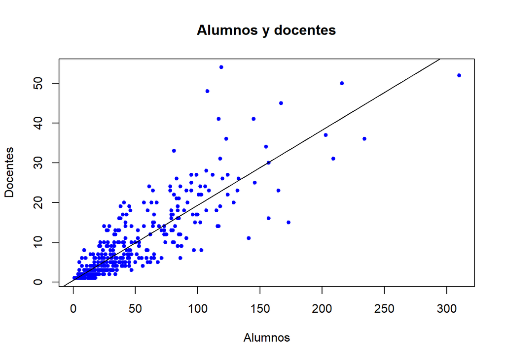

```r
plot(Data$`Alumnos (2015)`, Data$`Docentes (2015)`, pch = 20, col = "blue", main = "Alumnos y docentes", xlab= "Alumnos", ylab = "Docentes")
abline(regresion1, col = "black")
```

#### **Data frame de instituciones especiales clasificadas por Departamentos - Nro de Alumnos - Nro de Docentes - Nro de Secciones**

En este apartado trabajaremos con la variable numérica de SECCIÓN en conjunto con DOCENTES y ALUMNOS. La variable SECCIÓN representa el número total de salones que tiene la Institución Educativa Especial.

| Departamento | Alumnos | Docentes | Secciones |
| --- | --- | --- | --- |
| Ancash | 57 | 20 | 11 |
| Ancash | 22 | 3 | 7 |
| Ancash | 23 | 3 | 7 |
| Ancash | 78 | 24 | 10 |
| Ancash | 123 | 36 | 11 |
| Ancash | 145 | 41 | 17 |
| Ancash | 84 | 9 | 5 |
| Ancash | 16 | 7 | 8 |
| Ancash | 47 | 7 | 12 |
| Arequipa | 41 | 10 | 11 |

[output cut: 463 more lines]

A la tabla anterior se le añaden 2 columnas, las cuales representaran la cantidad de alumnos por sección (al_sec) y la cantidad de docentes por sección (sec_doc):

| Departamento | Alumnos | Docentes | Secciones | al_Sec | doc_Sec |
| --- | --- | --- | --- | --- | --- |
| Ancash | 57 | 20 | 11 | 5.181818 | 1.8181818 |
| Ancash | 22 | 3 | 7 | 3.142857 | 0.4285714 |
| Ancash | 23 | 3 | 7 | 3.285714 | 0.4285714 |
| Ancash | 78 | 24 | 10 | 7.800000 | 2.4000000 |
| Ancash | 123 | 36 | 11 | 11.181818 | 3.2727273 |
| Ancash | 145 | 41 | 17 | 8.529412 | 2.4117647 |
| Ancash | 84 | 9 | 5 | 16.800000 | 1.8000000 |
| Ancash | 16 | 7 | 8 | 2.000000 | 0.8750000 |
| Ancash | 47 | 7 | 12 | 3.916667 | 0.5833333 |
| Arequipa | 41 | 10 | 11 | 3.727273 | 0.9090909 |

[output cut: 463 more lines]

A continuación se mostrará la distribución de alumnos por sección y la de docentes por sección:

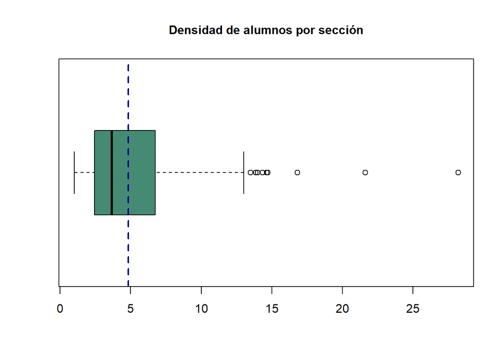

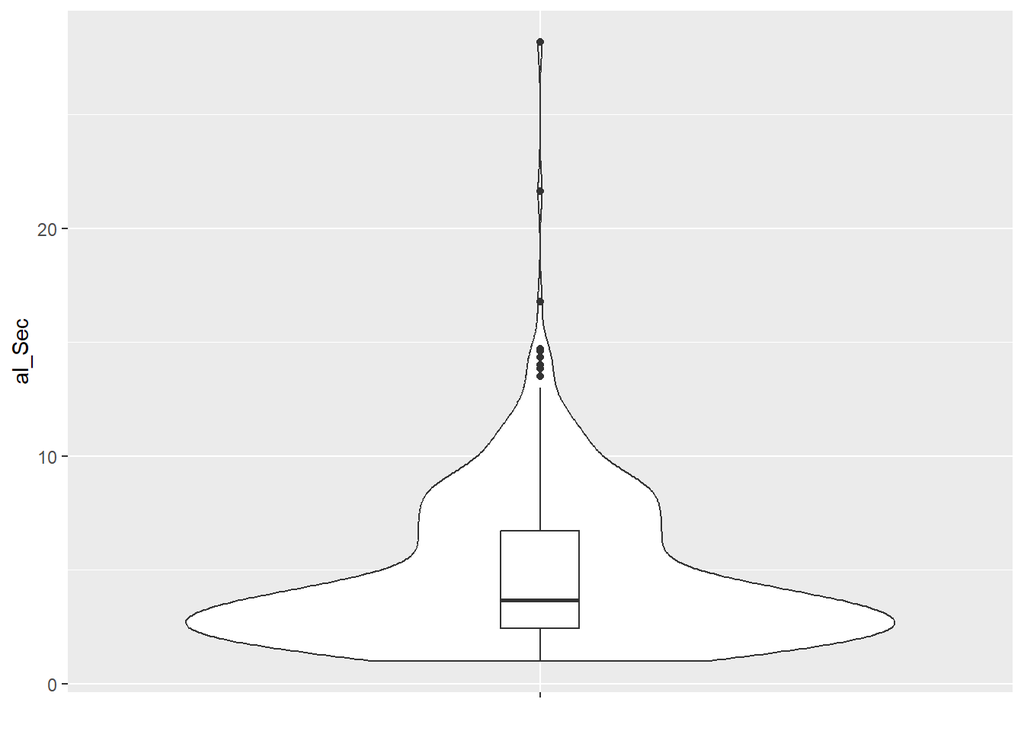

Usando nuevamente el gráfico de violin podemos ver mejor representada la distribución de alumnos por sección a lo largo del boxplot. Se observa que la mayoría de los datos se encuentran por debajo de la media. De igual forma, una cantidad similar se encuentra aproximadamente entre el segundo y cuarto cuartil .

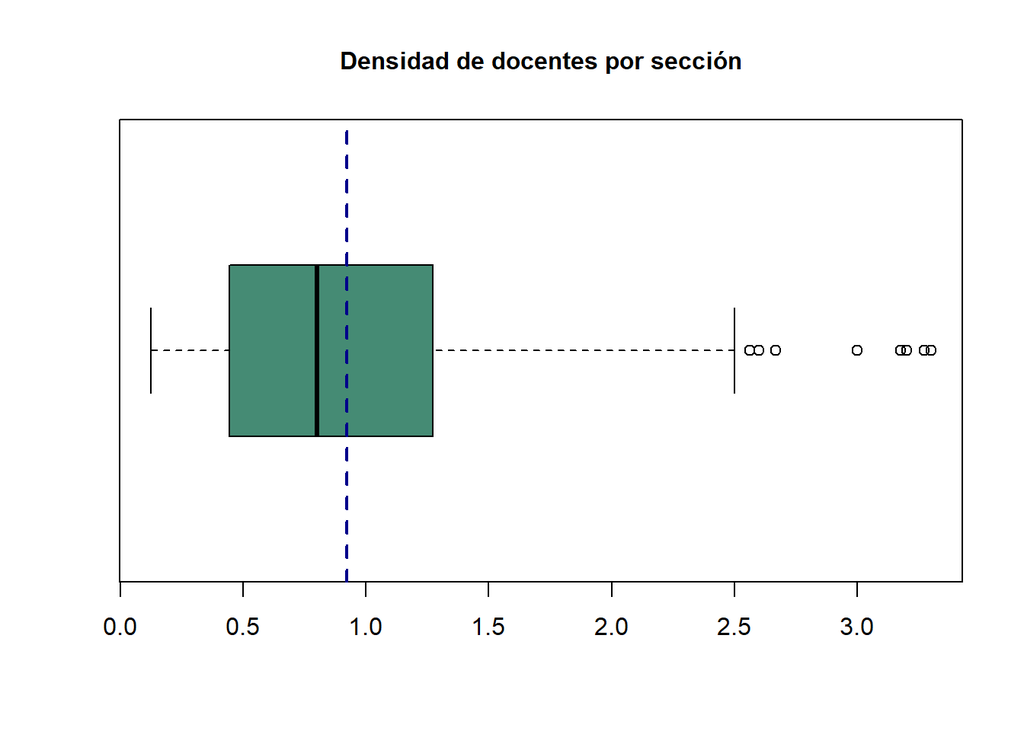

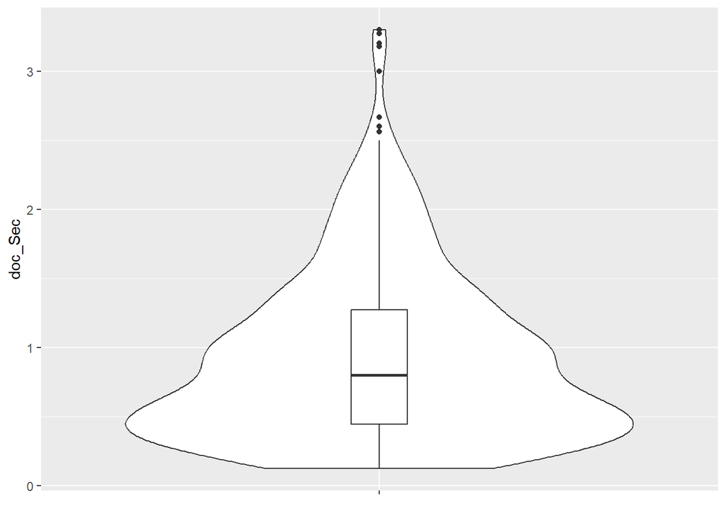

Para el caso de docentes por sección ocurre algo peculiar: se podría estimar que la cantidad de datos disminuye de forma lineal a medida que aumenta el valor de la variable mencionada.

Además de ello, la cantidad de docentes por sección varía entre 0.5 y 1.5 en la mayoría de instituciones educativas especiales. Esto nos indica que en gran parte de estas no hay 1 profesor asignado a una sección, lo que se podría considerar como el requisito mínimo para que se de una educación de calidad. Por el contrario, hay otras intituciones donde existen entre 2.5 y 3.5 docentes por sección.

**Para la variable alumnos por sección**

```r
ASV <- DSeccionDistribution %＞% plot_ly(x = "", y = ~al_Sec, type = 'violin',
                     box = list(visible = TRUE, width = 0.2))

htmlwidgets::saveWidget(ASV, "ASV.html")
display_html('＜iframe src="ASV.html" width=600 height=600 frameborder="0"＞＜/iframe＞')
```

**Para la variable docentes por sección**

```r
DSV <- DSeccionDistribution %＞% plot_ly(x = "", y = ~doc_Sec, type = 'violin',
                     box = list(visible = TRUE, width = 0.2))

htmlwidgets::saveWidget(DSV, "DSV.html")
display_html('＜iframe src="DSV.html" width=600 height=600 frameborder="0"＞＜/iframe＞')
```

Para continuar, como se realizo con las variables ALUMNOS y DOCENTES, se puede observar el comportamiento y relación de estas nuevas variables en un grafico de dispersión:

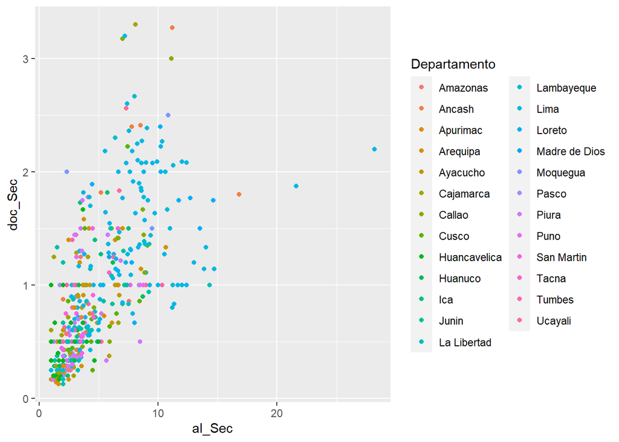

Además de solo mostrar los puntos se muestra la que región a la que pertenece. A pesar de ello, los datos se encuentran muy acumulados en la parte inferior izquierda, por lo que se realiza un gráfico con coordenadas logarítmicas:

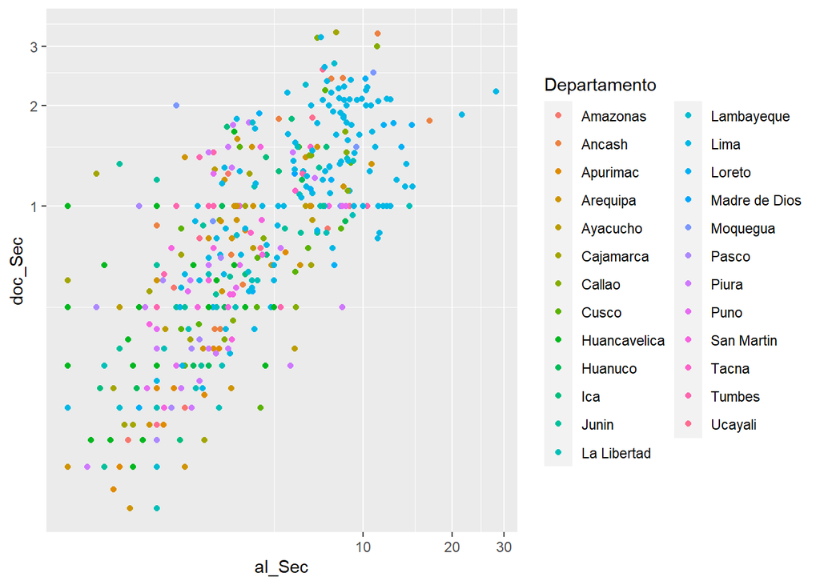

```r
Dispercion_Al_Doc_Sec<- ggplot(DSeccionDistribution, aes(x = al_Sec, y = doc_Sec,
                     color = Departamento)) +
  geom_point(alpha = 1) + coord_trans(x="log",y="log")

a <- Dispercion_Al_Doc_Sec +
  scale_color_brewer(palette = "Set1") +
  ggtitle("Dispersión de alumnos por sección - docentes por sección por departamento")
Dispercion_Al_Doc_Sec
```

Debido a que las variables ahora conforman prácticamente una relación lineal gracias a la transformación a coordenadas logarítmicas, se puede especular un tipo de comportamiento logarítmico para estas variables.

#### **Variables numéricas separadas por departamentos**

Una vez visto el comportamiento de los datos con respecto a las Instituciones Educativas, es aconsejable observar un plano general y manifestar si este comportamiento se sigue dando aún en cada departamento. Para esto, se agrupa la data original por departamento, sumando la cantidad de alumnos y docentes que esten en una Institución Educativa perteneciente a cierto departamento.

| Departamento | Alumnos |
| --- | --- |
| Amazonas | 149 |
| Ancash | 620 |
| Apurimac | 296 |
| Arequipa | 1028 |
| Ayacucho | 262 |
| Cajamarca | 380 |
| Callao | 971 |
| Cusco | 800 |
| Huancavelica | 190 |
| Huanuco | 233 |

[output cut: 15 more lines]

| Departamento | Docentes |
| --- | --- |
| Amazonas | 33 |
| Ancash | 155 |
| Apurimac | 40 |
| Arequipa | 217 |
| Ayacucho | 42 |
| Cajamarca | 93 |
| Callao | 217 |
| Cusco | 141 |
| Huancavelica | 41 |
| Huanuco | 35 |

[output cut: 15 more lines]

```
##  Departamento          Alumnos
##  Length:25          Min.   :  47.0
##  Class :character   1st Qu.: 233.0
##  Mode  :character   Median : 337.0
##                     Mean   : 751.1
##                     3rd Qu.: 685.0
##                     Max.   :8451.0
```

```
## [1] 1630.063
```

```
##  Departamento          Docentes
##  Length:25          Min.   :  10.0
##  Class :character   1st Qu.:  41.0
##  Mode  :character   Median :  80.0
##                     Mean   : 150.1
##                     3rd Qu.: 141.0
##                     Max.   :1627.0
```

```
## [1] 312.8591
```

#### **Evaluación de las variables numéricas con respecto a los departamentos**

Dado que esta evaluación llega a ser ligeramente similar al caso anterior, se mantienen los mismos descriptores numéricos.

| Descriptores numéricos para alumnos |  |
| --- | --- |
| Media | ~ 751 alumnos |
| 1° Cuartil | 233 alumnos |
| Mediana | 337 alumnos |
| 3° Cuartil | 685 alumnos |
| Máximo valor | 8451 alumnos |
| Desviación estándar | ~ 1630 alumnos |

| Descriptores numéricos para docentes |  |
| --- | --- |
| Media | ~ 150 docentes |
| 1° Cuartil | 41 docentes |
| Mediana | 80 docentes |
| 3° Cuartil | 141 docentes |
| Máximo valor | 1627 docentes |
| Desviación estándar | ~ 313 docentes |

```
## [1] 39.97175
```

```
## [1] 8.782908
```

#### **Histogramas**

El uso de histogramas se debe a que al conglomerar las variables numéricas por departamentos el numero de datos atípicos se ve considerablemente reducido. Por lo tanto, para visualizar mejor su comportamiento resulta factible dividirlo en intervalos y medir la frecuencia con la que ocurren.

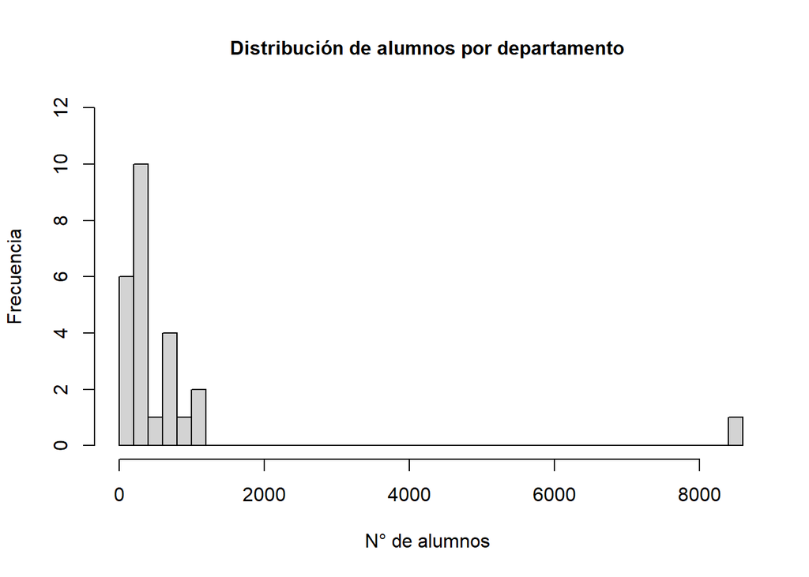

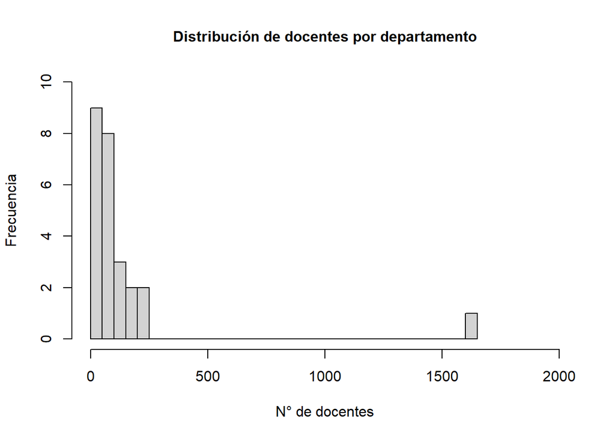

**HIPÓTESIS:** Las instituciones tienen la necesidad de ser numerosas para así poder satisfacer a toda la población especial en territorio peruano. No obstante, como esta es una minoría, entonces las instituciones tienden a tener un número bajo de docentes, ya que poseen un número limitado de alumnos. Las excepciones ocurren en departamentos como Lima, ya que aquí la población está altamente concentrada, así que se presentan instituciones con alto número tanto de profesores como alumnos.

##### **Apartado de regresión para las variables alumnos por departamento y docentes por departamento**

Se procura nuevamente vincular los datos conglomerados por departamentos para realizar el análisis del comportamiento de estas variables.

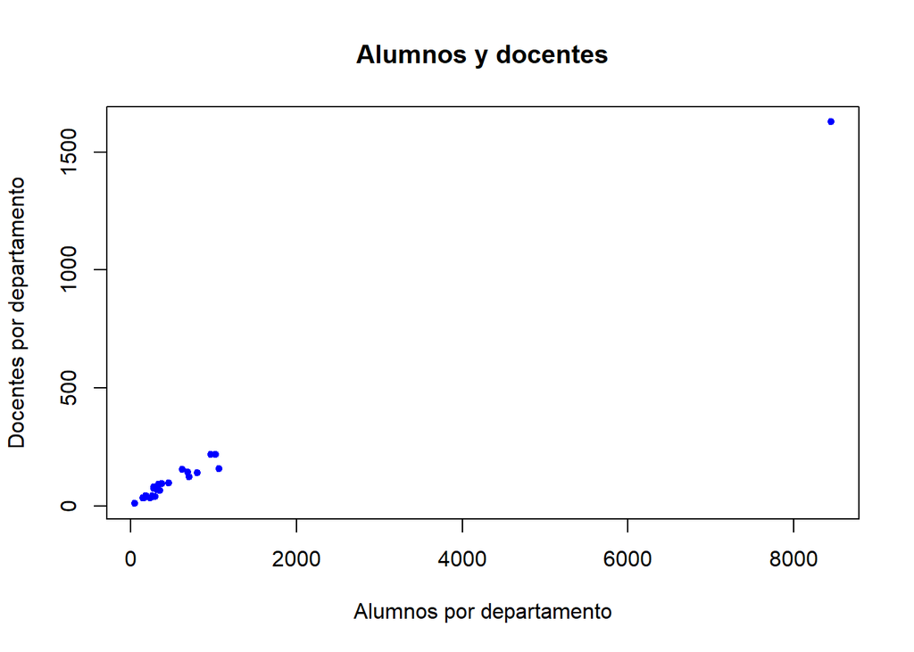

```r
# Covarianza
cov(D4$Alumnos, D5$Docentes)
```

```
## [1] 509095
```

Este valor nos confirma que a medida que una de las variables aumenta la otra lo hará de igual manera, una relación positiva.

```r
# Correlación
cov(D4$Alumnos, D5$Docentes)/(sd(D4$Alumnos)*(sd(D5$Docentes)))
```

```
## [1] 0.9982643
```

La formulación anterior puede ser corroborada con la función “cor” que se muestra a continuación:

```r
cor(data1)
```

```
##           X1        X2
## X1 1.0000000 0.9982643
## X2 0.9982643 1.0000000
```

De manera consecuente podemos intentar recrear una función lineal que pueda seguir el comportamiento de los datos:

```r
regresion <- lm(D5$Docentes ~ D4$Alumnos, data = data1)
summary(regresion)
```

```
##
## Call:
## lm(formula = D5$Docentes ~ D4$Alumnos, data = data1)
##
## Residuals:
##     Min      1Q  Median      3Q     Max
## -54.418  -9.809  -0.237  14.018  30.035
##
## Coefficients:
##             Estimate Std. Error t value Pr(>|t|)
## (Intercept) 6.174923   4.159719   1.484    0.151
## D4$Alumnos  0.191598   0.002357  81.293   <2e-16 ***
## ---
## Signif. codes:  0 '***' 0.001 '**' 0.01 '*' 0.05 '.' 0.1 ' ' 1
##
## Residual standard error: 18.82 on 23 degrees of freedom
## Multiple R-squared:  0.9965, Adjusted R-squared:  0.9964
## F-statistic:  6608 on 1 and 23 DF,  p-value: < 2.2e-16
```

En síntesis, con estos resultados se puede afirmar que:

**Alrededor del 99.65% de la variación de la variable docentes por departamento es explicada por la regresión y = 6.174923 + 0.191598x**

**Para el coeficiente de intersección paramétrico: bajo la prueba de hipotesis a un 5% de significancia se acepta la hipótesis nula, dado que su pvalor es igual a 0.151**

**Para el coeficiente de regresión paramétrico: bajo la prueba de hipótesis a un 5% de significancia se rechaza la hipótesis nula, dado que su pvalor es 2e-16**

Esto quiere decir que el intercepto con el eje “y” probablemente sea equivalente a 0. De la misma forma, significa que el coeficiente de regresión paramétrico es distinto de 0, por lo que la función es lineal.

Se puede ver cómo es que la nube de datos llega a ser concordante con el comportamiento de la función lineal.

Hay que resaltar además que el intervalo en donde se pueden realizar las respectivas predicciones es [47, 8451], es decir el valor minimo y el valor maximo de la variable alumnos por departamento.

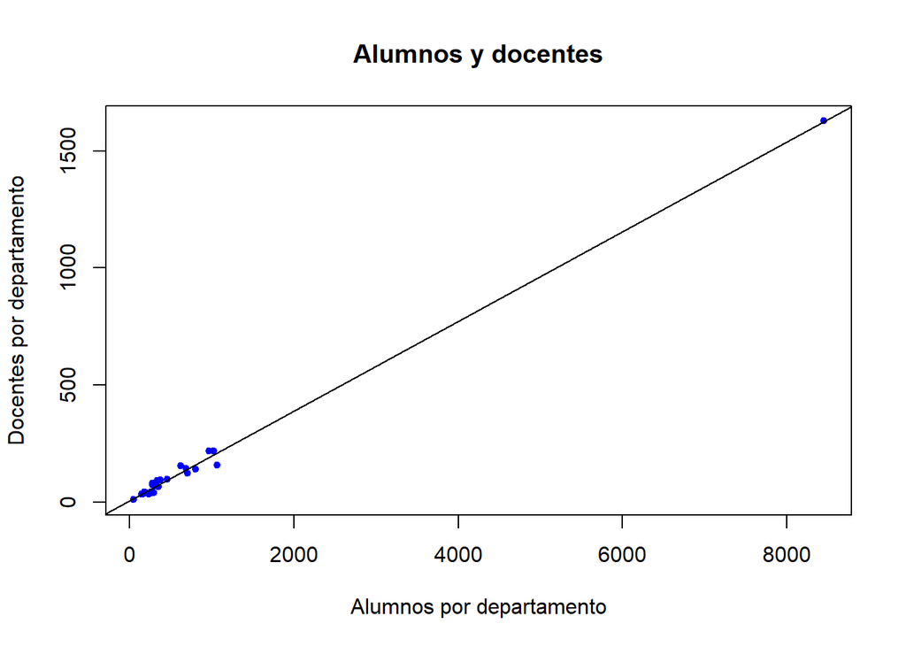

```r
plot(D4$Alumnos, D5$Docentes, pch = 20, col = "blue", main = "Alumnos y docentes", xlab= "Alumnos por departamento", ylab = "Docentes por departamento")
abline(regresion, col = "black")
```

##### **Regresión Múltiple**

Ahora, probaremos el modelo de regresión múltiple para predecir el número de docentes en la región costa. La razón por la que escogimos esta variable es porque nos interesa saber cómo estarán formadas las aulas en cuanto a personal educativo relacionadas con las otras dos variables (alumnos y secciones) en los años después de la toma de datos (2015).

```r
DCosta<-Data %>% filter(Departamento=="Ancash"| Departamento=="Callao"| Departamento=="Ica"| Departamento=="Lima"| Departamento=="Piura"| Departamento=="La Libertad"|Departamento=="Arequipa"|Departamento=="Moquegua"|Departamento=="Tacna"|Departamento=="Lambayeque"| Departamento=="Tumbes"| Departamento=="Callao")
DCosta
```

| Código modular | Código de local | Nombre de IE | Nivel / Modalidad | Forma | Gestión / Dependencia | Dirección de IE | Departamento | Provincia | Distrito | Alumnos (2015) | Docentes (2015) | Secciones (2015) |
| --- | --- | --- | --- | --- | --- | --- | --- | --- | --- | --- | --- | --- |
| 0909721 | 015775 | SEÑOR DE LOS MILAGROS | Educación Especial | Escolarizado | Pública - Sector Educación | AVENIDA SIMON BOLIVAR S/N | Ancash | Huaraz | Huaraz | 57 | 20 | 11 |
| 0681726 | 026905 | SAN ANTONIO DE PADUA | Educación Especial | Escolarizado | Pública - Sector Educación | JIRON BOLOGNESI S/N | Ancash | Huaylas | Caraz | 22 | 3 | 7 |
| 1003151 | 037602 | CEBE AULA DE EDUCACION ESPECIAL 01 SANTA | Educación Especial | Escolarizado | Pública - Sector Educación | MZ W LOTE 1 | Ancash | Santa | Santa | 23 | 3 | 7 |
| 1000306 | 038041 | CEBE 03 | Educación Especial | Escolarizado | Pública - Sector Educación | JIRON 31 | Ancash | Santa | Nuevo Chimbote | 78 | 24 | 10 |
| 0570226 | 034793 | CEBE 01 | Educación Especial | Escolarizado | Pública - Sector Educación | MZ P LOTE 24-25 | Ancash | Santa | Chimbote | 123 | 36 | 11 |
| 0359323 | 035641 | CEBE FE Y ALEGRIA 42 | Educación Especial | Escolarizado | Pública - En convenio | AVENIDA JOSE PARDO 4071 MZ 13 LOTE 01 | Ancash | Santa | Chimbote | 145 | 41 | 17 |
| 1001627 | 529058 | PRITE LA VICTORIA | Educación Especial | No escolarizado | Pública - Sector Educación | MZ 6 LOTE 26-B ZONA II | Ancash | Santa | Chimbote | 84 | 9 | 5 |
| 0818518 | 022323 | 02 AGUSTIN EVANS | Educación Especial | Escolarizado | Pública - Sector Educación | CALLE MARISCAL SUCRE | Ancash | Casma | Casma | 16 | 7 | 8 |
| 1042399 | 026118 | 04 VIRGEN DEL ROSARIO | Educación Especial | Escolarizado | Pública - Sector Educación | CARRETERA PANAMERICANA NORTE KM.293 | Ancash | Huarmey | Huarmey | 47 | 7 | 12 |
| 0637330 | 072407 | CENTRO ESPECIAL MOLLENDO | Educación Especial | Escolarizado | Pública - Sector Educación | CALLE PUNO 710 | Arequipa | Islay | Mollendo | 41 | 10 | 11 |

[output cut: 279 more lines]

```r
modelo<-lm( `Docentes (2015)`~ `Alumnos (2015)`+`Secciones (2015)`, data = DCosta)
summary(modelo)
```

```
##
## Call:
## lm(formula = `Docentes (2015)` ~ `Alumnos (2015)` + `Secciones (2015)`,
##     data = DCosta)
##
## Residuals:
##      Min       1Q   Median       3Q      Max
## -15.0581  -2.6490  -0.2407   2.0038  27.7815
##
## Coefficients:
##                    Estimate Std. Error t value Pr(>|t|)
## (Intercept)        -3.26232    0.66102  -4.935 1.36e-06 ***
## `Alumnos (2015)`    0.12736    0.01028  12.384  < 2e-16 ***
## `Secciones (2015)`  0.84267    0.11141   7.564 5.38e-13 ***
## ---
## Signif. codes:  0 '***' 0.001 '**' 0.01 '*' 0.05 '.' 0.1 ' ' 1
##
## Residual standard error: 4.684 on 286 degrees of freedom
## Multiple R-squared:  0.7701, Adjusted R-squared:  0.7685
## F-statistic:   479 on 2 and 286 DF,  p-value: < 2.2e-16
```

Como observamos, el coeficiente de determinación es grande (0.7701), por lo que el modelo predecirá adecuadamente el número de docentes. Además, vemos que el p-valor para el intercepto (1.36e-06) es menor a la significancia (0.1), por lo que la Ho (ßo = 0) se rechaza. Para los demás coeficientes se cumple lo ya explicado (2e-16 < 0.1, 5.38e-13 < 0.1), por lo que las Ho (ß1 = 0 y ß2 = 0) se rechazan, con lo que tenemos que el modelo propuesto sí es un modelo significativo.

Así, analizamos la correlación entre las variables.

```r
DatosCos<-data.frame(DCosta[11],DCosta[12],DCosta[13])
cor <- round(cor(x = DatosCos, method = "pearson"), 3)
cor
```

```
##                  Alumnos..2015. Docentes..2015. Secciones..2015.
## Alumnos..2015.            1.000           0.851            0.791
## Docentes..2015.           0.851           1.000            0.804
## Secciones..2015.          0.791           0.804            1.000
```

Como observamos, se tiene una correlación relativamente alta de 0.791 entre alumnos y secciones, por lo que no se considera apropiado su uso para realizar predicciones. Por ende, lo más adecuado es trabajar con un modelo de regresión lineal simple.

Pasando al analisis de otras variables:

| Departamento | Alumnos | Docentes | Secciones |
| --- | --- | --- | --- |
| Amazonas | 149 | 33 | 49 |
| Ancash | 620 | 155 | 95 |
| Apurimac | 296 | 40 | 102 |
| Arequipa | 1028 | 217 | 271 |
| Ayacucho | 262 | 42 | 63 |
| Cajamarca | 380 | 93 | 117 |
| Callao | 971 | 217 | 141 |
| Cusco | 800 | 141 | 149 |
| Huancavelica | 190 | 41 | 82 |
| Huanuco | 233 | 35 | 50 |

[output cut: 15 more lines]

| Departamento | Alumnos | Docentes | Secciones | AlumnosPorSeccion | DocentesPorSeccion |
| --- | --- | --- | --- | --- | --- |
| Amazonas | 149 | 33 | 49 | 3.040816 | 0.6734694 |
| Ancash | 620 | 155 | 95 | 6.526316 | 1.6315789 |
| Apurimac | 296 | 40 | 102 | 2.901961 | 0.3921569 |
| Arequipa | 1028 | 217 | 271 | 3.793358 | 0.8007380 |
| Ayacucho | 262 | 42 | 63 | 4.158730 | 0.6666667 |
| Cajamarca | 380 | 93 | 117 | 3.247863 | 0.7948718 |
| Callao | 971 | 217 | 141 | 6.886525 | 1.5390071 |
| Cusco | 800 | 141 | 149 | 5.369128 | 0.9463087 |
| Huancavelica | 190 | 41 | 82 | 2.317073 | 0.5000000 |
| Huanuco | 233 | 35 | 50 | 4.660000 | 0.7000000 |

[output cut: 15 more lines]

Asimismo, podemos organizar estos datos y verlos mejor representados a traves de un gráfico de barras:

**Para la variable AlumnosPorSeccion**

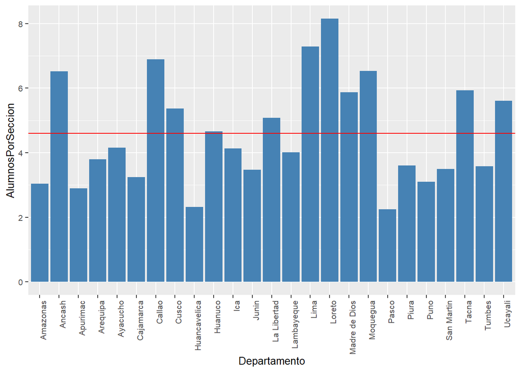

**Para la variable DocentesPorSeccion**

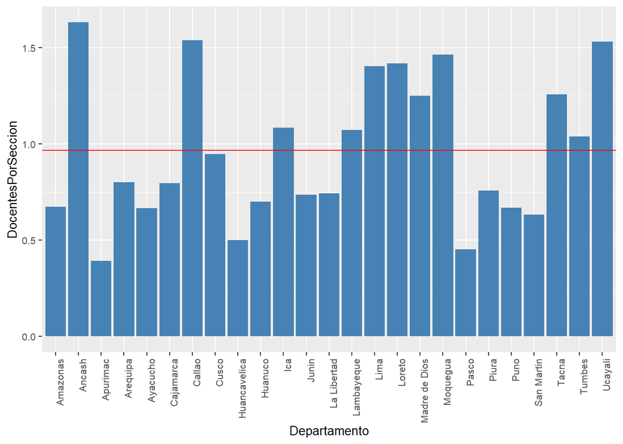

Para este caso se hizo un procedimiento similar al anterior gráfico, solo que usando el total de docentes, en lugar del de alumnos. Seguidamente se le dividió entre el total de secciones. En este gráfico se observa que los departamentos donde hay mayor concentración de docentes por sección son Áncash, Callao, Ucayali y Moquegua. Igualmente, aquellos donde la densidad es menor son Apurímac, Pasco, Huancavelica y San Martín. Asimismo, la media de docentes por sección por departamento es de 0.97.

#### **Evaluación de las variables categóricas nominales**

Para la siguiente parte de nuestro analisis nos centraremos en los departamentos y cantidad de colegios escolarizados, privados y publicos que hay en cada uno. Para este caso se utilizaron las variables categoricas de FORMA, GESTIÓN y DEPARTAMENTO de la data original, las cuales conforman un nuevo data.frame denominado “Publi_priv.csv” el cual estará adjunto con el resto de archivos.

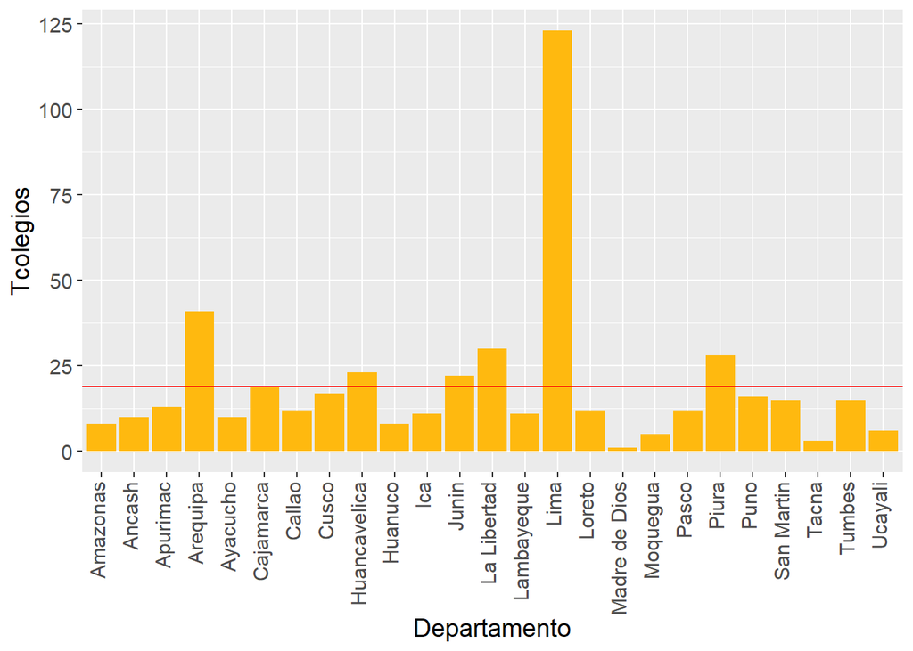

```r
# Gráfica Total de colegios

Nuevo2 %>% ggplot(aes(x = Departamento, y=Tcolegios), main = "Instituciones Educativas", xlab = "Departamento", ylab = "Colegios") + geom_col (fill=colors()[76])+ geom_hline(yintercept=mean(Nuevo2$Tcolegios), color="red") + theme(text = element_text(size=14),
        axis.text.x = element_text(angle=90, hjust=1,vjust = 0.2))
```

En esta gráfica se observa que la mayoría cantidad de colegios se encuentran en Lima, la cual es alrededor de 3 veces mayor que la segunda más alta, Arequipa. Esta relación concuerda con la población de ambos departamentos, ya que ambos poseen las poblaciones más grandes del país.

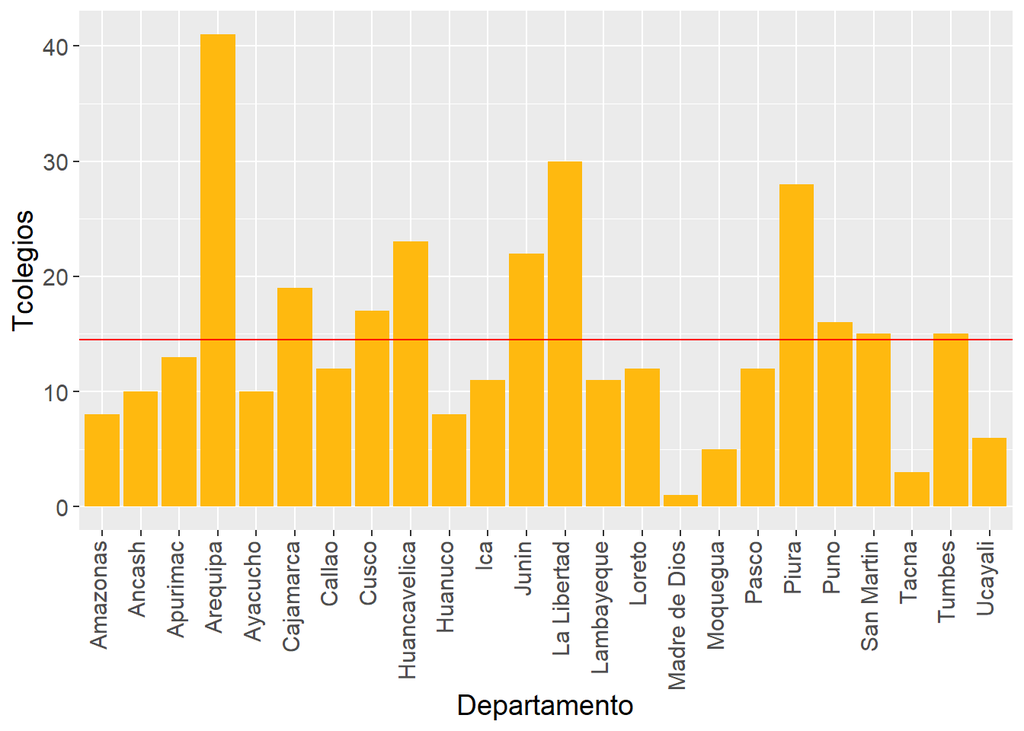

```r
# Tcolegios sin Lima(Gráfico)
Tcol_xlima<-Nuevo2[Nuevo2$Tcolegios < 100, ]

Tcol_xlima %>% ggplot(aes(x = Departamento, y=Tcolegios), main = "Instituciones Educativas", xlab = "Departamento", ylab = "Colegios") + geom_col (fill=colors()[76])+ geom_hline(yintercept=mean(Tcol_xlima$Tcolegios), color="red") + theme(text = element_text(size=14),
        axis.text.x = element_text(angle=90, hjust=1,vjust = 0.2))
```

```r
# Departamento con MAYOR numero de colegios
slice(Nuevo2,which.max(Tcolegios))
```

| Departamento | Escolarizado | No Escolarizado | Publica | Privada | Tcolegios |
| --- | --- | --- | --- | --- | --- |
| Lima | 107 | 16 | 92 | 31 | 123 |

```r
# Departamento con MENOR numero de colegios
slice(Nuevo2,which.min(Tcolegios))
```

| Departamento | Escolarizado | No Escolarizado | Publica | Privada | Tcolegios |
| --- | --- | --- | --- | --- | --- |
| Madre de Dios | 1 | 0 | 1 | 0 | 1 |

```r
# ORDEN (Escolarizado y No escolarizado)

# Departamentos coN MENOR cantidad de colegios escolarizados
EscolarizadaLOW <- Nuevo2[order(Nuevo2$Escolarizado), ]
head(EscolarizadaLOW)
```

| Departamento | Escolarizado | No Escolarizado | Publica | Privada | Tcolegios |
| --- | --- | --- | --- | --- | --- |
| Madre de Dios | 1 | 0 | 1 | 0 | 1 |
| Moquegua | 3 | 2 | 5 | 0 | 5 |
| Tacna | 3 | 0 | 2 | 1 | 3 |
| Ucayali | 4 | 2 | 6 | 0 | 6 |
| Huanuco | 6 | 2 | 7 | 1 | 8 |
| Amazonas | 7 | 1 | 8 | 0 | 8 |

```r
# Departamentos con MAYOR cantidad de colegios escolarizados
EscolarizadaUP<-EscolarizadaLOW[nrow(EscolarizadaLOW):1, ]
head(EscolarizadaUP)
```

| Departamento | Escolarizado | No Escolarizado | Publica | Privada | Tcolegios |
| --- | --- | --- | --- | --- | --- |
| Lima | 107 | 16 | 92 | 31 | 123 |
| Arequipa | 36 | 5 | 32 | 9 | 41 |
| La Libertad | 28 | 2 | 24 | 6 | 30 |
| Piura | 25 | 3 | 23 | 5 | 28 |
| Huancavelica | 20 | 3 | 23 | 0 | 23 |
| Junin | 17 | 5 | 20 | 2 | 22 |

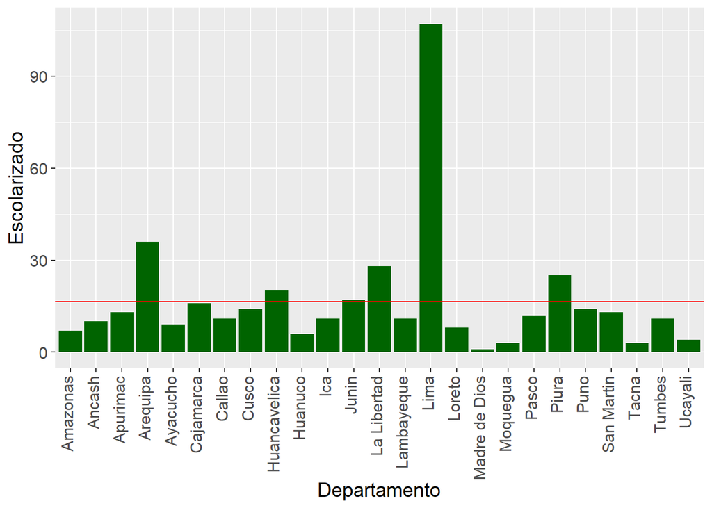

```r
# Gráfica de escolarizados
Nuevo2 %>% ggplot(aes(x = Departamento, y=Escolarizado), main = "Frecuencia de escolarizado", xlab = "Departamento", ylab = "Escolarizados") + geom_col (fill="darkgreen")+ geom_hline(yintercept=mean(Nuevo2$Escolarizado), color="red") + theme(text = element_text(size=14),
        axis.text.x = element_text(angle=90, hjust=1,vjust = 0.2))
```

Se aprecia que las instituciones escolarizadas siguen una tendencia muy similar a la de todas las instituciones en conjunto, donde Lima lidera con diferencia.

```r
# Escolarizados sin contar Lima(Dataframe)
ED_sinlima<-EscolarizadaUP[EscolarizadaUP$Escolarizado < 60, ]
head(ED_sinlima)
```

| Departamento | Escolarizado | No Escolarizado | Publica | Privada | Tcolegios |
| --- | --- | --- | --- | --- | --- |
| Arequipa | 36 | 5 | 32 | 9 | 41 |
| La Libertad | 28 | 2 | 24 | 6 | 30 |
| Piura | 25 | 3 | 23 | 5 | 28 |
| Huancavelica | 20 | 3 | 23 | 0 | 23 |
| Junin | 17 | 5 | 20 | 2 | 22 |
| Cajamarca | 16 | 3 | 18 | 1 | 19 |

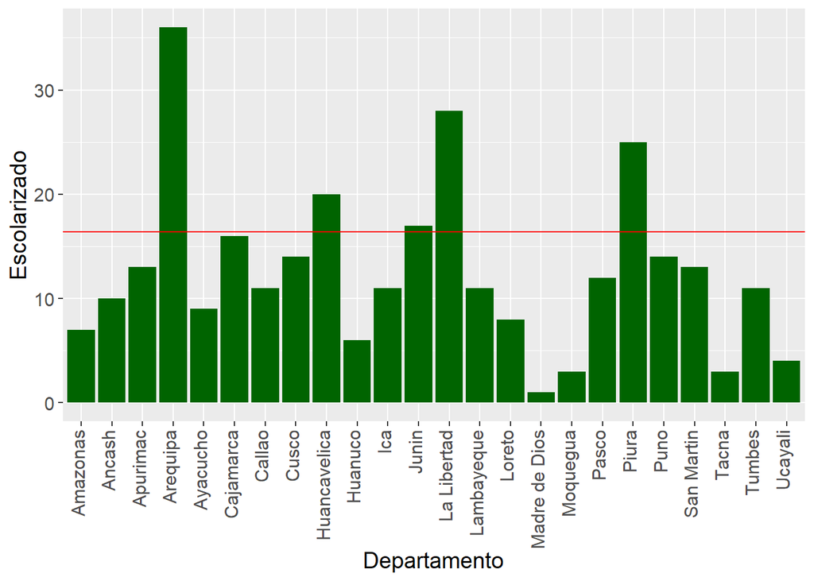

```r
# GRÁFICA de escolarizados sin contar lima
ED_sinlima %>% ggplot(aes(x = Departamento, y=Escolarizado), main = "Frecuencia de escolarizado", xlab = "Departamento sin Lima", ylab = "Escolarizados") + geom_col (fill="darkgreen")+ geom_hline(yintercept=mean(Nuevo2$Escolarizado), color="red") + theme(text = element_text(size=14),
        axis.text.x = element_text(angle=90, hjust=1,vjust = 0.2))
```

```r
# GESTIÓN (PUBLICA O PRIVADA)

# Privados

# Orden Privados

# Departamentos con MAYOR gestion PRIVADA
PrivLOW <- Nuevo2[order(Nuevo2$Privada), ]
PrivUP<-PrivLOW[nrow(PrivLOW):1, ]
head(PrivUP)
```

| Departamento | Escolarizado | No Escolarizado | Publica | Privada | Tcolegios |
| --- | --- | --- | --- | --- | --- |
| Lima | 107 | 16 | 92 | 31 | 123 |
| Pasco | 12 | 1 | 0 | 12 | 12 |
| Arequipa | 36 | 5 | 32 | 9 | 41 |
| La Libertad | 28 | 2 | 24 | 6 | 30 |
| Piura | 25 | 3 | 23 | 5 | 28 |
| Junin | 17 | 5 | 20 | 2 | 22 |

```r
# Sin contar LIMA
Privup_sinlima<-PrivUP[PrivUP$Privada < 22, ]
head(Privup_sinlima)
```

| Departamento | Escolarizado | No Escolarizado | Publica | Privada | Tcolegios |
| --- | --- | --- | --- | --- | --- |
| Pasco | 12 | 1 | 0 | 12 | 12 |
| Arequipa | 36 | 5 | 32 | 9 | 41 |
| La Libertad | 28 | 2 | 24 | 6 | 30 |
| Piura | 25 | 3 | 23 | 5 | 28 |
| Junin | 17 | 5 | 20 | 2 | 22 |
| Puno | 14 | 2 | 14 | 2 | 16 |

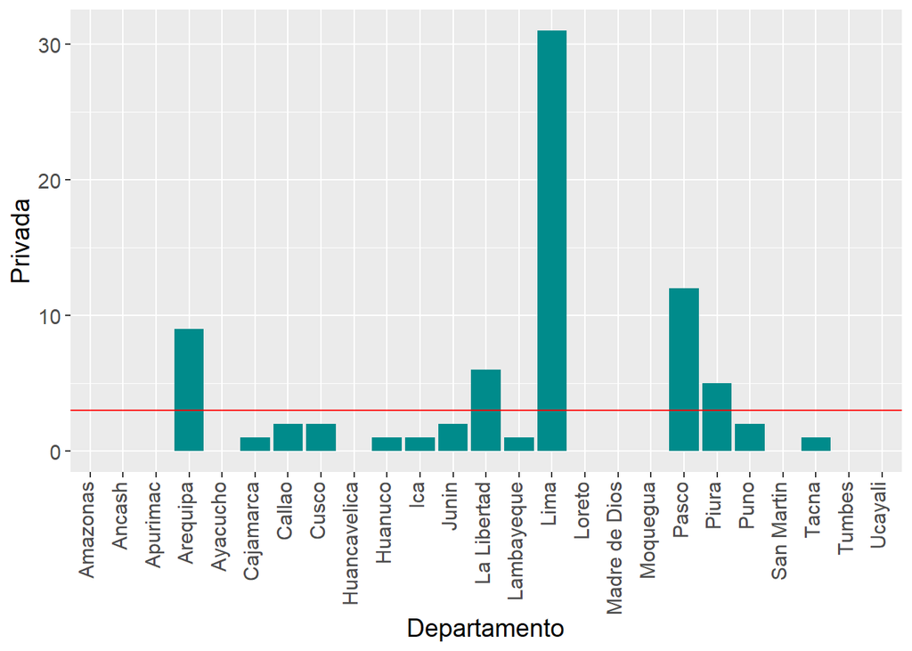

```r
# GRÁFICA DE COLEGIOS ESPECIALES PRIVADOS EN EL PERÚ
Nuevo2 %>% ggplot(aes(x = Departamento, y= Privada), main = "Frecuencia de gestio privada", xlab = "Departamento", ylab = "Escolarizados") + geom_col (fill=colors()[72])+ geom_hline(yintercept=mean(Nuevo2$Privada), color="red") + theme(text = element_text(size=14),
        axis.text.x = element_text(angle=90, hjust=1,vjust = 0.2))
```

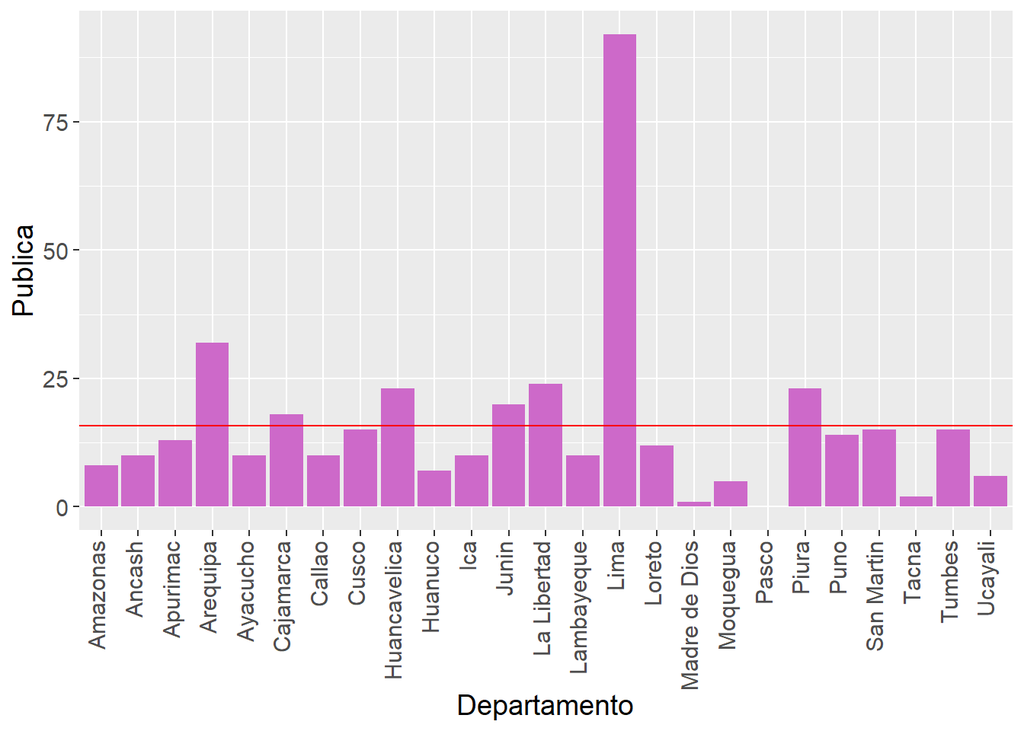

```r
# GRÁFICA DE COLEGIOS ESPECIALES PUBLICOS EN EL PERÚ

Nuevo2 %>% ggplot(aes(x = Departamento, y= Publica), main = "Frecuencia de gestio pública", xlab = "Departamento", ylab = "Privados") + geom_col (fill=colors()[511])+ geom_hline(yintercept=mean(Nuevo2$Publica), color="red") + theme(text = element_text(size=14),
        axis.text.x = element_text(angle=90, hjust=1,vjust = 0.2))
```

En estas últimas dos gráficas se aprecia que la cantidad de instituciones en el Departamento de Lima es considerablemente mayor a la media. Asimismo, se observa que la cantidad de instituciones públicas es notablemente mayor a la cantidad de instituciones privadas, hasta el punto que departamentos principalmente rurales como Amazonas, Loreto y Moquegua carecen de instituciones privadas.

Para representar gráficamente la frecuencia de la cantidad de alumnos por tipo de escuela se usó el histograma, ya que nos permite agrupar en intervalos la cantidad de alumnos. Con esto podemos ver que la tendencia son las instituciones con menos alumnado.

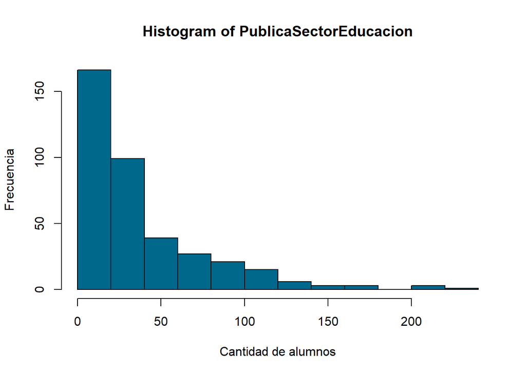

```r
PublicaSectorEducacion<-Col_Espe$`Alumnos (2015)`[which(Col_Espe$`Gestión / Dependencia`=="Pública - Sector Educación")]
PublicaEnconvenio<-Col_Espe$`Alumnos (2015)`[which(Col_Espe$`Gestión / Dependencia`=="Pública - En convenio")]
PrivadaInstitucionesBeneficas<-Col_Espe$`Alumnos (2015)`[which(Col_Espe$`Gestión / Dependencia`=="Privada - Instituciones Benéficas")]
PrivadaParticular<-Col_Espe$`Alumnos (2015)`[which(Col_Espe$`Gestión / Dependencia`=="Privada - Particular")]
PrivadaParroquial<-Col_Espe$`Alumnos (2015)`[which(Col_Espe$`Gestión / Dependencia`=="Privada - Parroquial")]
hist(PublicaSectorEducacion,xlab = "Cantidad de alumnos", ylab="Frecuencia",col=colors()[125])
```

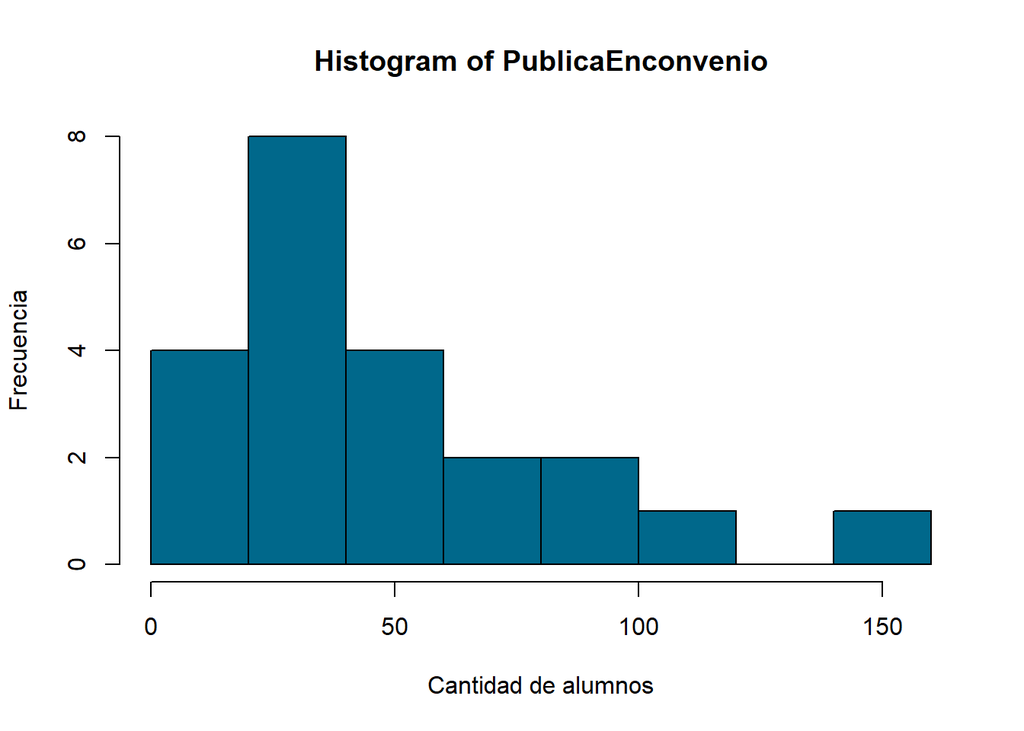

```r
hist(PublicaEnconvenio,xlab = "Cantidad de alumnos", ylab="Frecuencia",col=colors()[125])
```

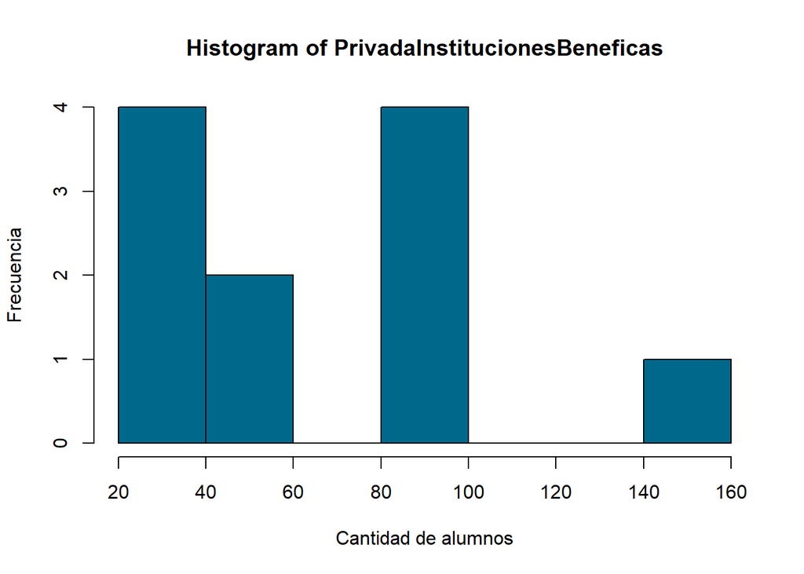

```r
hist(PrivadaInstitucionesBeneficas,xlab = "Cantidad de alumnos", ylab="Frecuencia",col=colors()[125])
```